# ****Please don’t review this yet*****

Meily Wu Fung

9/18/2017

```
## 'data.frame':    35310 obs. of  13 variables:
##  $ STATION: Factor w/ 1 level "USW00023272": 1 1 1 1 1 1 1 1 1 1 ...
##  $ NAME   : Factor w/ 1 level "SAN FRANCISCO DOWNTOWN, CA US": 1 1 1 1 1 1 1 1 1 1 ...
##  $ DATE   : Factor w/ 35310 levels "1921-01-01","1921-01-02",..: 1 2 3 4 5 6 7 8 9 10 ...
##  $ DAPR   : int  NA NA NA NA NA NA NA NA NA NA ...
##  $ MDPR   : num  NA NA NA NA NA NA NA NA NA NA ...
##  $ PRCP   : num  0 0 0 0 0.38 0.01 0 0 0 0 ...
##  $ SNOW   : num  0 0 0 0 0 0 0 0 0 0 ...
##  $ SNWD   : int  NA NA NA NA NA NA NA NA NA NA ...
##  $ TAVG   : int  NA NA NA NA NA NA NA NA NA NA ...
##  $ TMAX   : int  60 54 60 61 54 51 53 55 54 54 ...
##  $ TMIN   : int  45 46 50 47 47 43 41 39 43 43 ...
##  $ TOBS   : int  NA NA NA NA NA NA NA NA NA NA ...
##  $ NewDate: Date, format: "1921-01-01" "1921-01-02" ...
```

plot data from select period of time in a month-basis

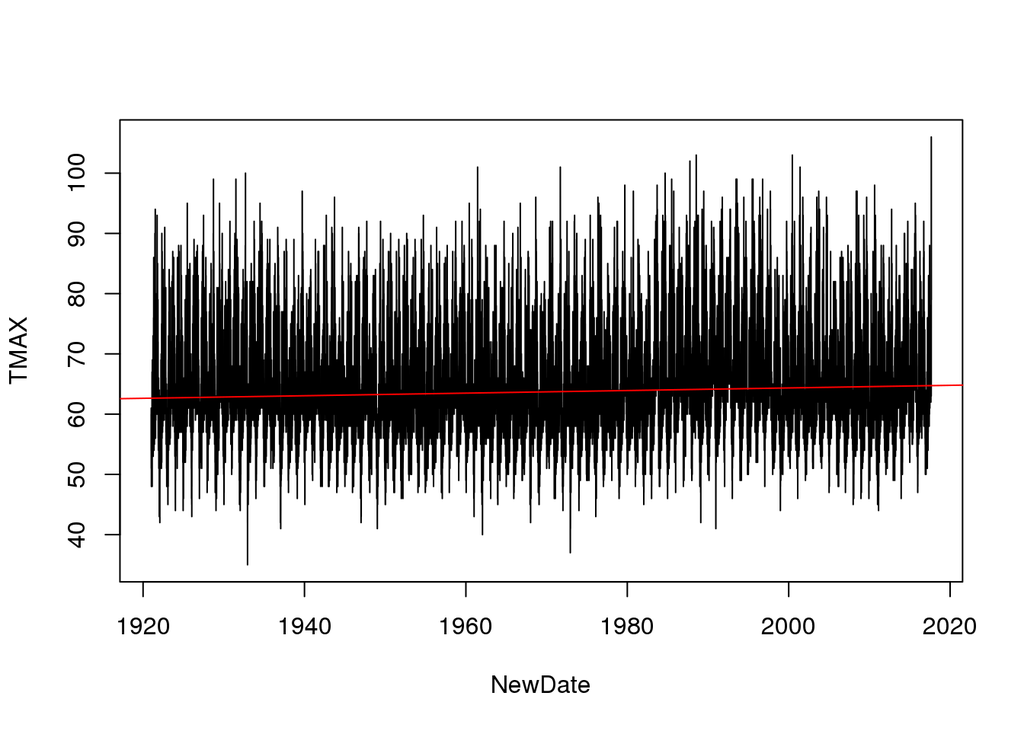

##Creating monthly TMAX Means

```
## 'data.frame':    1161 obs. of  5 variables:
##  $ Month: chr  "01" "02" "03" "04" ...
##  $ Year : chr  "1921" "1921" "1921" "1921" ...
##  $ TMAX : num  54.4 59.6 60.4 62.2 60.5 ...
##  $ YEAR : num  1921 1921 1921 1921 1921 ...
##  $ MONTH: num  1 2 3 4 5 6 7 8 9 10 ...
```

```
##
## Call:
## lm(formula = TMAX ~ YEAR, data = MonthlyTMAXMean[MonthlyTMAXMean$Month ==
##     "01", ])
##
## Residuals:
##     Min      1Q  Median      3Q     Max
## -6.6582 -1.5611 -0.1981  1.5292  5.8611
##
## Coefficients:
##               Estimate Std. Error t value Pr(>|t|)
## (Intercept) -29.406261  16.812413  -1.749   0.0835 .
## YEAR          0.043699   0.008538   5.118  1.6e-06 ***
## ---
## Signif. codes:  0 '***' 0.001 '**' 0.01 '*' 0.05 '.' 0.1 ' ' 1
##
## Residual standard error: 2.354 on 95 degrees of freedom
## Multiple R-squared:  0.2162, Adjusted R-squared:  0.2079
## F-statistic:  26.2 on 1 and 95 DF,  p-value: 1.605e-06
```

[figure not shown]

```
##
## Call:
## lm(formula = TMAX ~ YEAR, data = MonthlyTMAXMean[MonthlyTMAXMean$Month ==
##     "02", ])
##
## Residuals:
##     Min      1Q  Median      3Q     Max
## -6.1895 -1.8065 -0.3992  1.5224  6.5457
##
## Coefficients:
##              Estimate Std. Error t value Pr(>|t|)
## (Intercept) 10.545192  18.721223   0.563  0.57457
## YEAR         0.025105   0.009507   2.641  0.00967 **
## ---
## Signif. codes:  0 '***' 0.001 '**' 0.01 '*' 0.05 '.' 0.1 ' ' 1
##
## Residual standard error: 2.622 on 95 degrees of freedom
## Multiple R-squared:  0.06838,    Adjusted R-squared:  0.05858
## F-statistic: 6.973 on 1 and 95 DF,  p-value: 0.009673
```

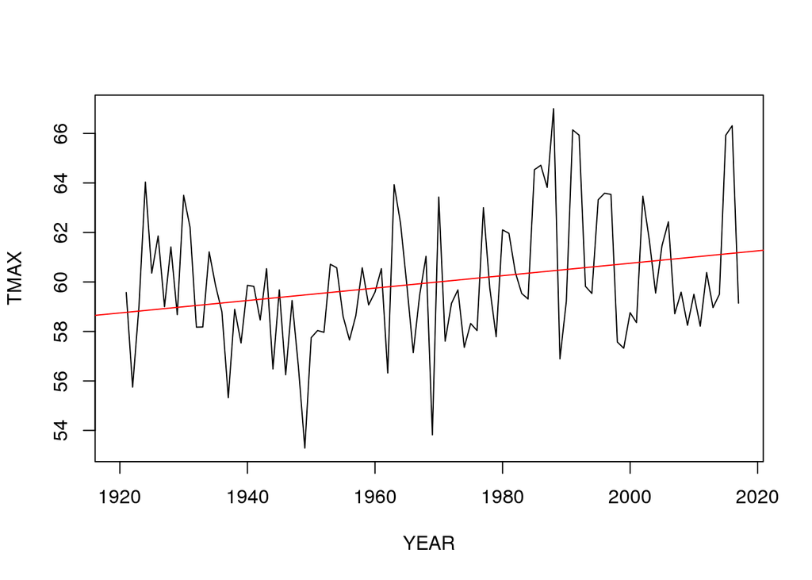

```
##
## Call:
## lm(formula = TMAX ~ YEAR, data = MonthlyTMAXMean[MonthlyTMAXMean$Month ==
##     "03", ])
##
## Residuals:
##     Min      1Q  Median      3Q     Max
## -5.9281 -2.3271 -0.3131  2.3639  7.1533
##
## Coefficients:
##             Estimate Std. Error t value Pr(>|t|)
## (Intercept) 30.29158   22.36998   1.354    0.179
## YEAR         0.01592    0.01136   1.401    0.164
##
## Residual standard error: 3.133 on 95 degrees of freedom
## Multiple R-squared:  0.02024,    Adjusted R-squared:  0.009931
## F-statistic: 1.963 on 1 and 95 DF,  p-value: 0.1645
```

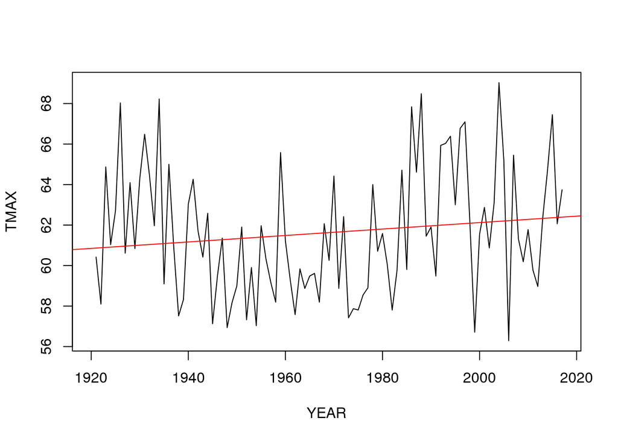

```
##
## Call:
## lm(formula = TMAX ~ YEAR, data = MonthlyTMAXMean[MonthlyTMAXMean$Month ==
##     "04", ])
##
## Residuals:
##     Min      1Q  Median      3Q     Max
## -7.5268 -1.7620 -0.0759  1.6623  8.1133
##
## Coefficients:
##             Estimate Std. Error t value Pr(>|t|)
## (Intercept) 31.88759   21.61474   1.475    0.143
## YEAR         0.01573    0.01098   1.433    0.155
##
## Residual standard error: 3.027 on 95 degrees of freedom
## Multiple R-squared:  0.02116,    Adjusted R-squared:  0.01085
## F-statistic: 2.053 on 1 and 95 DF,  p-value: 0.1551
```

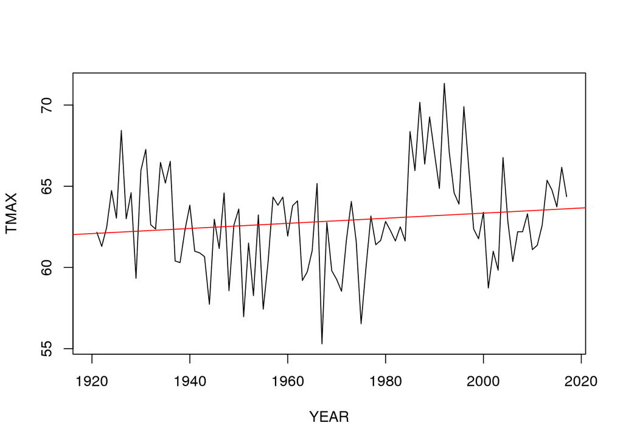

```
##
## Call:
## lm(formula = TMAX ~ YEAR, data = MonthlyTMAXMean[MonthlyTMAXMean$Month ==
##     "05", ])
##
## Residuals:
##     Min      1Q  Median      3Q     Max
## -5.7417 -2.0393 -0.2827  1.7227  6.6510
##
## Coefficients:
##             Estimate Std. Error t value Pr(>|t|)
## (Intercept) 41.28968   20.61170   2.003    0.048 *
## YEAR         0.01156    0.01047   1.105    0.272
## ---
## Signif. codes:  0 '***' 0.001 '**' 0.01 '*' 0.05 '.' 0.1 ' ' 1
##
## Residual standard error: 2.886 on 95 degrees of freedom
## Multiple R-squared:  0.01268,    Adjusted R-squared:  0.002291
## F-statistic:  1.22 on 1 and 95 DF,  p-value: 0.2721
```

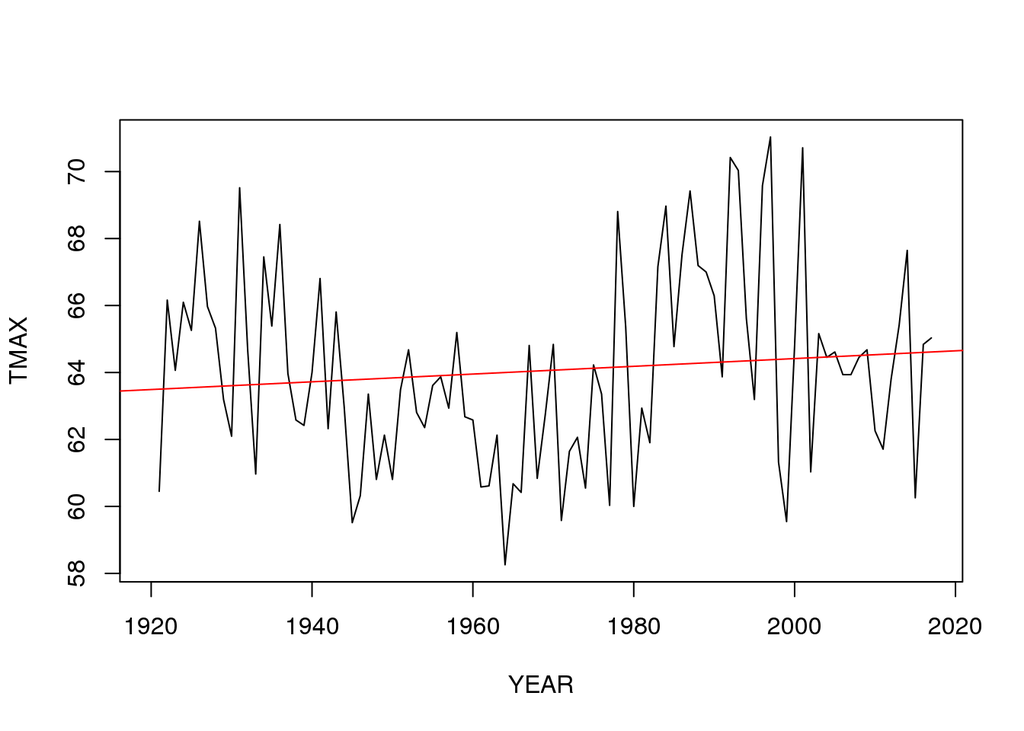

```
##
## Call:
## lm(formula = TMAX ~ YEAR, data = MonthlyTMAXMean[MonthlyTMAXMean$Month ==
##     "06", ])
##
## Residuals:
##     Min      1Q  Median      3Q     Max
## -5.6318 -1.9124 -0.3182  2.4088  9.3648
##
## Coefficients:
##             Estimate Std. Error t value Pr(>|t|)
## (Intercept) 35.73393   20.20457   1.769   0.0802 .
## YEAR         0.01545    0.01026   1.506   0.1353
## ---
## Signif. codes:  0 '***' 0.001 '**' 0.01 '*' 0.05 '.' 0.1 ' ' 1
##
## Residual standard error: 2.829 on 95 degrees of freedom
## Multiple R-squared:  0.02333,    Adjusted R-squared:  0.01304
## F-statistic: 2.269 on 1 and 95 DF,  p-value: 0.1353
```

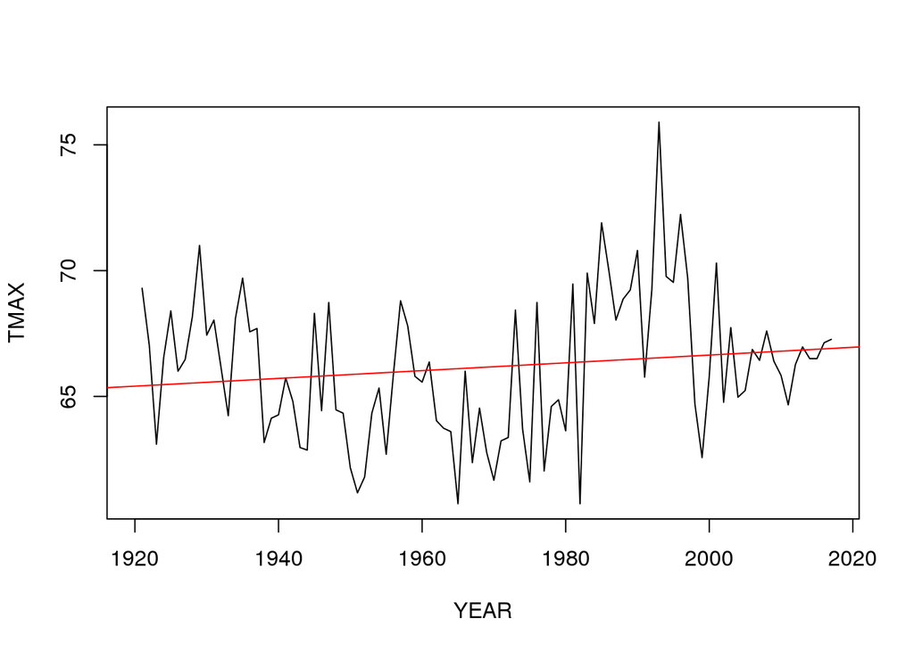

```
##
## Call:
## lm(formula = TMAX ~ YEAR, data = MonthlyTMAXMean[MonthlyTMAXMean$Month ==
##     "07", ])
##
## Residuals:
##     Min      1Q  Median      3Q     Max
## -5.2378 -1.9185 -0.4927  1.4459  7.2938
##
## Coefficients:
##             Estimate Std. Error t value Pr(>|t|)
## (Intercept) 11.05905   19.31774   0.572  0.56835
## YEAR         0.02788    0.00981   2.842  0.00549 **
## ---
## Signif. codes:  0 '***' 0.001 '**' 0.01 '*' 0.05 '.' 0.1 ' ' 1
##
## Residual standard error: 2.705 on 95 degrees of freedom
## Multiple R-squared:  0.07834,    Adjusted R-squared:  0.06864
## F-statistic: 8.075 on 1 and 95 DF,  p-value: 0.005491
```

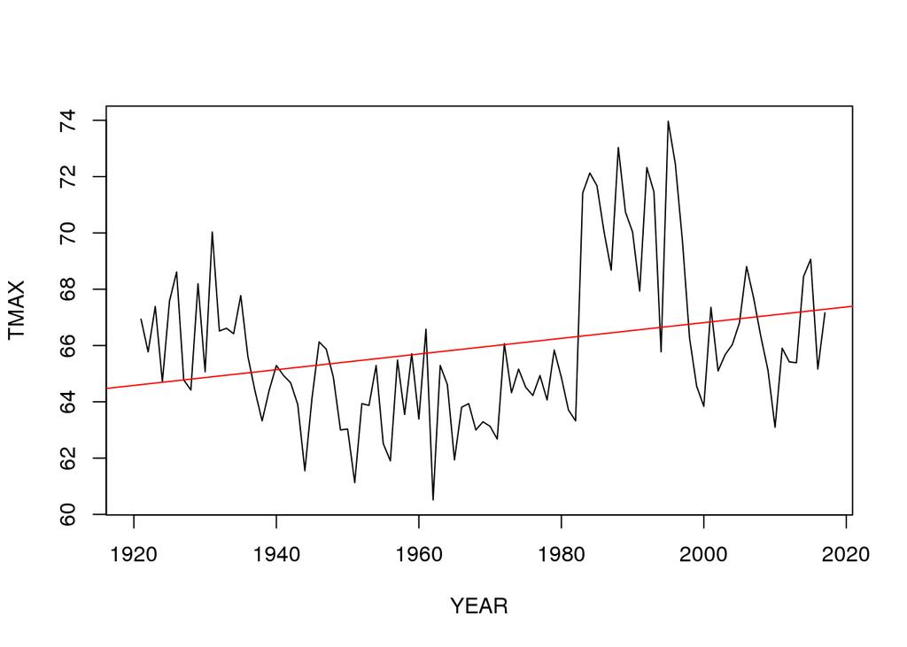

```
##
## Call:
## lm(formula = TMAX ~ YEAR, data = MonthlyTMAXMean[MonthlyTMAXMean$Month ==
##     "08", ])
##
## Residuals:
##     Min      1Q  Median      3Q     Max
## -5.0931 -1.7273 -0.4034  1.5601  7.4289
##
## Coefficients:
##              Estimate Std. Error t value Pr(>|t|)
## (Intercept) -8.856022  18.597835  -0.476    0.635
## YEAR         0.038412   0.009444   4.067 9.82e-05 ***
## ---
## Signif. codes:  0 '***' 0.001 '**' 0.01 '*' 0.05 '.' 0.1 ' ' 1
##
## Residual standard error: 2.604 on 95 degrees of freedom
## Multiple R-squared:  0.1483, Adjusted R-squared:  0.1393
## F-statistic: 16.54 on 1 and 95 DF,  p-value: 9.819e-05
```

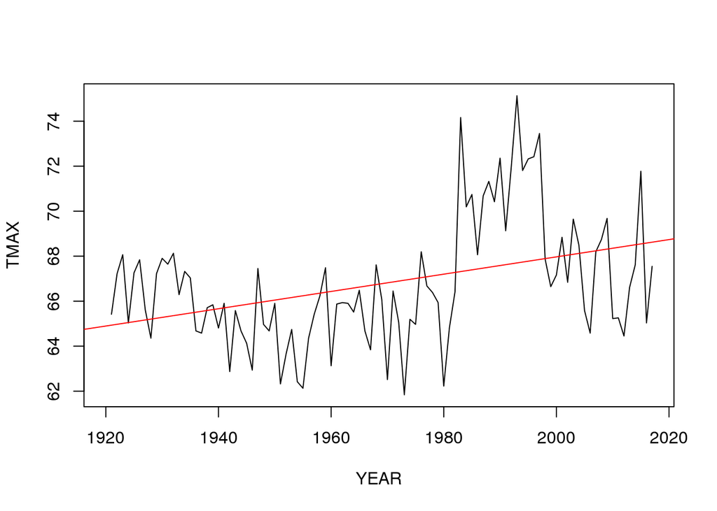

```
##
## Call:
## lm(formula = TMAX ~ YEAR, data = MonthlyTMAXMean[MonthlyTMAXMean$Month ==
##     "09", ])
##
## Residuals:
##     Min      1Q  Median      3Q     Max
## -7.4477 -2.2269 -0.2695  1.5764 21.1075
##
## Coefficients:
##             Estimate Std. Error t value Pr(>|t|)
## (Intercept)  6.48590   25.58042   0.254   0.8004
## YEAR         0.03230    0.01299   2.487   0.0146 *
## ---
## Signif. codes:  0 '***' 0.001 '**' 0.01 '*' 0.05 '.' 0.1 ' ' 1
##
## Residual standard error: 3.582 on 95 degrees of freedom
## Multiple R-squared:  0.06112,    Adjusted R-squared:  0.05123
## F-statistic: 6.184 on 1 and 95 DF,  p-value: 0.01464
```

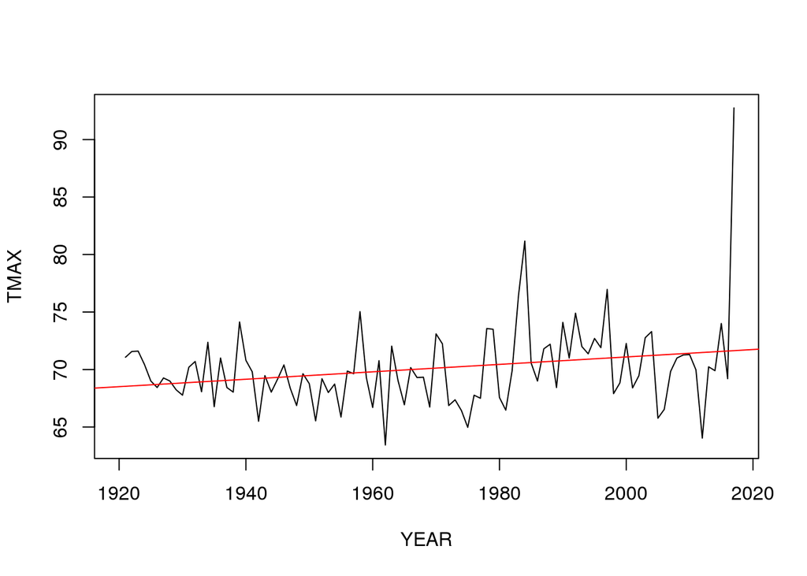

```
##
## Call:
## lm(formula = TMAX ~ YEAR, data = MonthlyTMAXMean[MonthlyTMAXMean$Month ==
##     "10", ])
##
## Residuals:
##     Min      1Q  Median      3Q     Max
## -4.9452 -1.6305 -0.2777  1.7313  6.1799
##
## Coefficients:
##             Estimate Std. Error t value Pr(>|t|)
## (Intercept) 31.33449   17.24523   1.817   0.0724 .
## YEAR         0.01924    0.00876   2.196   0.0305 *
## ---
## Signif. codes:  0 '***' 0.001 '**' 0.01 '*' 0.05 '.' 0.1 ' ' 1
##
## Residual standard error: 2.378 on 94 degrees of freedom
## Multiple R-squared:  0.04881,    Adjusted R-squared:  0.03869
## F-statistic: 4.824 on 1 and 94 DF,  p-value: 0.03053
```

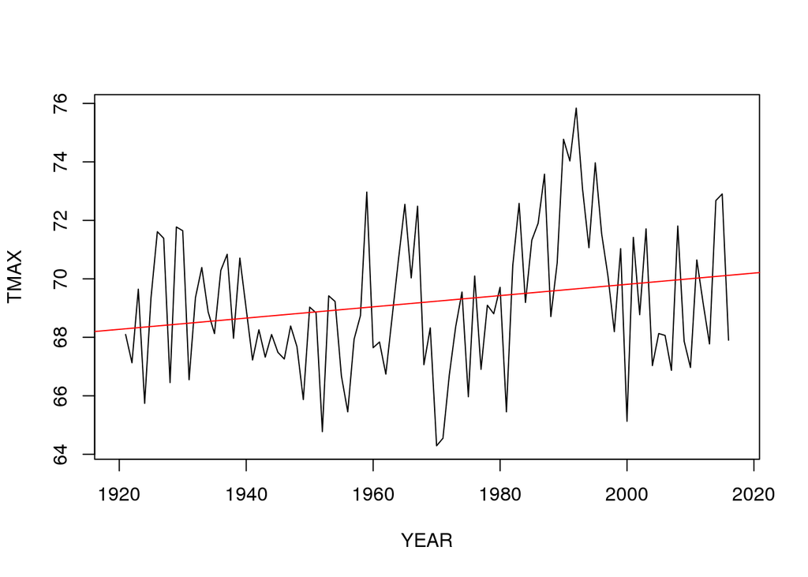

```
##
## Call:
## lm(formula = TMAX ~ YEAR, data = MonthlyTMAXMean[MonthlyTMAXMean$Month ==
##     "11", ])
##
## Residuals:
##     Min      1Q  Median      3Q     Max
## -5.4647 -2.0782 -0.2415  1.9354  5.9033
##
## Coefficients:
##              Estimate Std. Error t value Pr(>|t|)
## (Intercept) 66.213862  19.522324   3.392  0.00102 **
## YEAR        -0.001262   0.009916  -0.127  0.89903
## ---
## Signif. codes:  0 '***' 0.001 '**' 0.01 '*' 0.05 '.' 0.1 ' ' 1
##
## Residual standard error: 2.692 on 94 degrees of freedom
## Multiple R-squared:  0.0001722,  Adjusted R-squared:  -0.01046
## F-statistic: 0.01619 on 1 and 94 DF,  p-value: 0.899
```

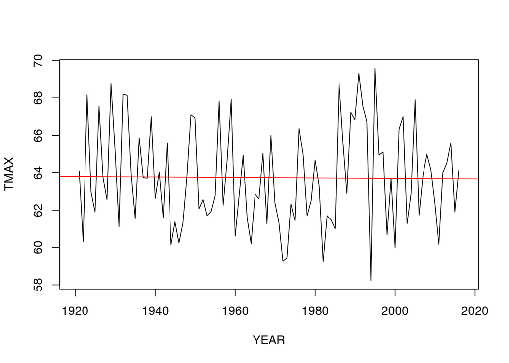

```
##
## Call:
## lm(formula = TMAX ~ YEAR, data = MonthlyTMAXMean[MonthlyTMAXMean$Month ==
##     "12", ])
##
## Residuals:
##     Min      1Q  Median      3Q     Max
## -5.8564 -1.5293 -0.0247  1.6249  6.6580
##
## Coefficients:
##             Estimate Std. Error t value Pr(>|t|)
## (Intercept) 16.81558   17.32472   0.971   0.3342
## YEAR         0.02062    0.00880   2.343   0.0213 *
## ---
## Signif. codes:  0 '***' 0.001 '**' 0.01 '*' 0.05 '.' 0.1 ' ' 1
##
## Residual standard error: 2.389 on 94 degrees of freedom
## Multiple R-squared:  0.05516,    Adjusted R-squared:  0.04511
## F-statistic: 5.488 on 1 and 94 DF,  p-value: 0.02126
```

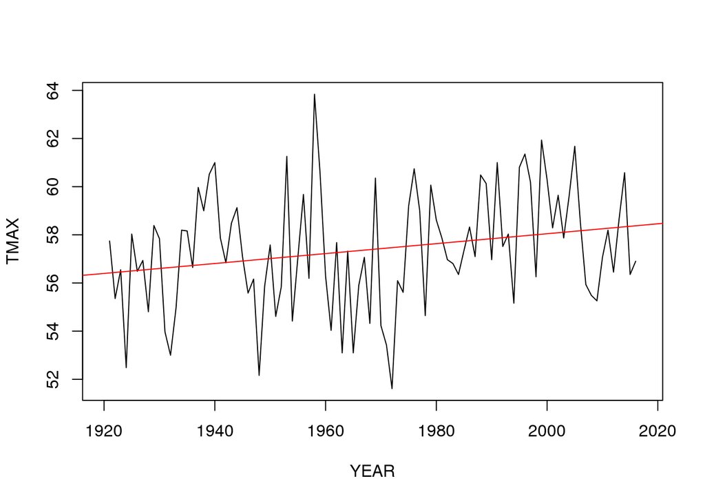

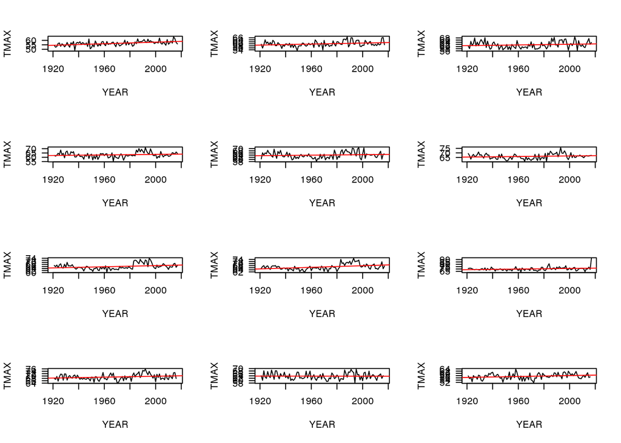

```
##   Month Year     TMIN YEAR MONTH
## 1    01 1921 44.54839 1921     1
## 2    02 1921 46.25000 1921     2
## 3    03 1921 48.67742 1921     3
## 4    04 1921 47.66667 1921     4
## 5    05 1921 48.16129 1921     5
## 6    06 1921 53.46667 1921     6
```

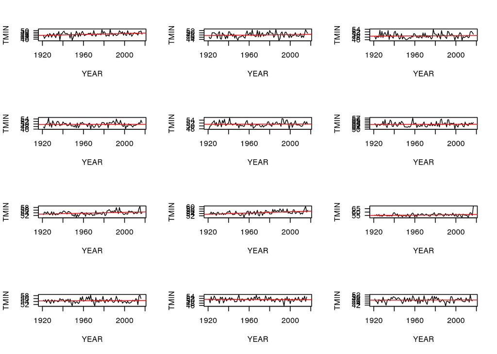

=====

## Discussion

The city of San Francisco is home to 870,000 residents, and is the fourth most populous city in California. Besides being the cultural, commercial and financial center of the larger San Francisco Bay Area, it attracts abundant tourists annually with its temperate climate and mix of landmarks. However, with an increasing trend of record-high temperatures and slowly rising average temperatures, climate change has potential threats in the city of San Francisco. Some of these include heat vulnerability, sea level and coastal change, extreme weather events, and air pollution. The San Francisco Department of Public Health, funded by the Center for Disease Control and Prevention (CDC) assesses San Francisco’s vulnerability to extreme heat events. The brink of what is considered an “extreme heat day” varies based on the historical average temperatures of the place being analysed. According to a synthesis of climate change impacts in the San Francisco Bay Area done for the California Energy Commission, the temperatures in the high 70s in coastal areas, including San Francisco, are considered extreme heat days, which are lower compared to more inland areas. However, this means that the number of days above these thresholds can be much greater for these coastal areas. For San Francisco, these days are expected to increase dramatically (Ekstrom).

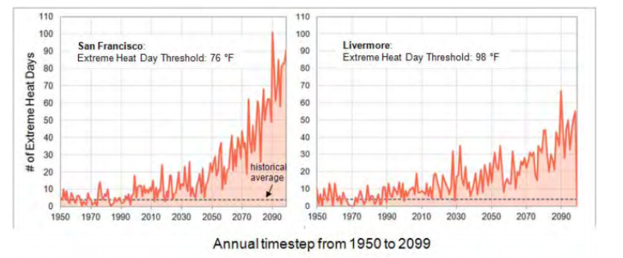